# jaynemorais-comentarios-e-cultura

devjaynemorais

27 de abril de 2019

```
Jayne Morais (Mestrado - FPCC2 - 2019.1)
```

```r
dados = read_csv(
    here::here("data/participation-per-country.csv"),
    col_types = cols(
        .default = col_double(),
        site = col_character(),
        country = col_character(),
        geo = col_character(),
        four_regions = col_character(),
        eight_regions = col_character(),
        six_regions = col_character(),
        `World bank income group 2017` = col_character()
    )
) %>%
    filter(usuarios > 200)
glimpse(dados)
```

```
## Observations: 121
## Variables: 21
## $ site                           <chr> "StackOverflow", "StackOverflow",…
## $ country                        <chr> "Argentina", "Australia", "Austri…
## $ PDI                            <dbl> 49, 36, 11, 80, 65, 69, 70, 39, 6…
## $ IDV                            <dbl> 46, 90, 55, 20, 75, 38, 30, 80, 2…
## $ MAS                            <dbl> 56, 61, 79, 55, 54, 49, 40, 52, 2…
## $ UAI                            <dbl> 86, 51, 70, 60, 94, 76, 85, 48, 8…
## $ usuarios                       <dbl> 2798, 12313, 2518, 2558, 4275, 10…
## $ responderam_prop               <dbl> 0.5357398, 0.6133355, 0.6310564, …
## $ perguntaram_prop               <dbl> 0.5210865, 0.5897832, 0.5933280, …
## $ editaram_prop                  <dbl> 0.09256612, 0.14699911, 0.1493248…
## $ comentaram_prop                <dbl> 0.25339528, 0.33395598, 0.3502780…
## $ GNI                            <dbl> NA, 59570, 48160, 840, 44990, 116…
## $ Internet                       <dbl> 51.0, 79.5, 79.8, 5.0, 78.0, 45.0…
## $ EPI                            <dbl> 59.02, NA, 63.21, NA, 61.21, 49.9…
## $ geo                            <chr> "arg", "aus", "aut", "bgd", "bel"…
## $ four_regions                   <chr> "americas", "asia", "europe", "as…
## $ eight_regions                  <chr> "america_south", "east_asia_pacif…
## $ six_regions                    <chr> "america", "east_asia_pacific", "…
## $ Latitude                       <dbl> -34.00000, -25.00000, 47.33333, 2…
## $ Longitude                      <dbl> -64.00000, 135.00000, 13.33333, 9…
## $ `World bank income group 2017` <chr> "Upper middle income", "High inco…
```

Estamos interessados na relação entre quanto as pessoas de diferentes países comentam em questões dos outros. A proporção das pessoas do país que comentou nas questões de outros está medido na variável `comentaram_prop`.

Considerando essa variável, queremos examinar a relação entre ela e o quão hierárquicas são as relações em um país (`PDI`). Queremos também levar em conta o quanto as pessoas daquele país têm acesso à Internet (`Internet`) e qual o tamanho da base de dados que detectamos daquele país (`usuarios`).

## Examinando essa relação

Faça uma visualização que usa os princípios de eficácia no projeto de visualizações para facilitar as comparações que você acha que são as mais importantes para entendermos esse contexto.

```
Para esa visualização foi utilizada a região espacial (eixos x e y) para relacionar as variáveis "a proporção de usuários que comentam" em ambos os sites e o "índice de distância de Potência", utilizou-se da luminosidade da cor para enfatizar o número de usuários em geral de ambos os sites, assim como o tamanho do círculo para determinar a proporção de acesso à internet de pessoas de um determinado país.

É possível observar que existe uma relação entre quanto maior a proporção de usuários que comentam os sites, menor é o índice de distância de potência, ou seja, nas sociedades ondem os usuários mais comentam nos sites, as pessoas tendem a se esforçar para igualar a distribuição de poder.

Também percebe-se que há uma relação entre quanto maior o númeo de usuários dos sites, também é maior o número de pessoas que contribuem através de comentários.
```

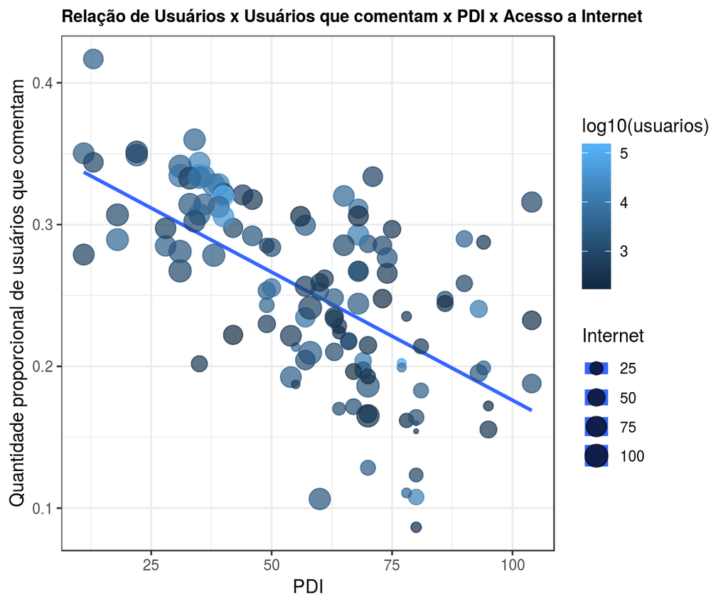

```r
analise1 = dados %>%
  select(comentaram_prop, PDI, Internet, usuarios) %>%
  ggplot(aes(
        x = PDI,
        y = comentaram_prop,
        size = Internet,
        color = log10(usuarios)
    )) +
    geom_smooth(aes(x = PDI, y = comentaram_prop), method = lm, se = FALSE) +
    geom_point(alpha = 0.7) +
    theme(plot.title = element_text(size = 10, face = "bold")) +
    labs(
    title = "Relação de Usuários x Usuários que comentam x PDI x Acesso a Internet",
    #subtitle = "João Pessoa X Campina grande",
    y = "Quantidade proporcional de usuários que comentam",
    x = "PDI"
  )
 #ggplotly(analise1)
analise1
```

## Outras formas de ver

Em seguida, faça 5 visualizações que usem as mesmas variáveis e também pontos, mas que sejam **menos eficazes** que a que você escolheu acima.

### 1 - Cor

[output not shown]

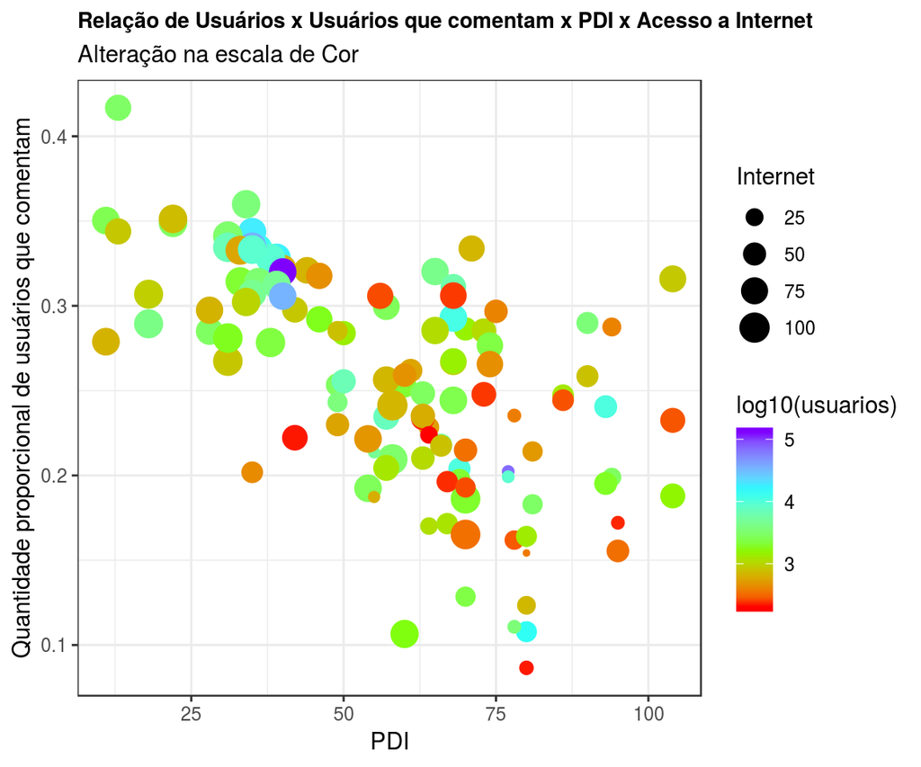

```r
analise1 = dados %>%
  select(comentaram_prop, PDI, Internet, usuarios) %>%
  ggplot(aes(
        x = PDI,
        y = comentaram_prop,
        size = Internet,
        color = log10(usuarios)
    )) +
  geom_point()+
  scale_colour_gradientn(colours=rainbow(4)) +
  theme(plot.title = element_text(size = 10, face = "bold")) +
    labs(
    title = "Relação de Usuários x Usuários que comentam x PDI x Acesso a Internet",
    subtitle = "Alteração na escala de Cor",
    y = "Quantidade proporcional de usuários que comentam",
    x = "PDI"
  )

analise1
```

### 2 - Preenchimento da Forma

[output not shown]

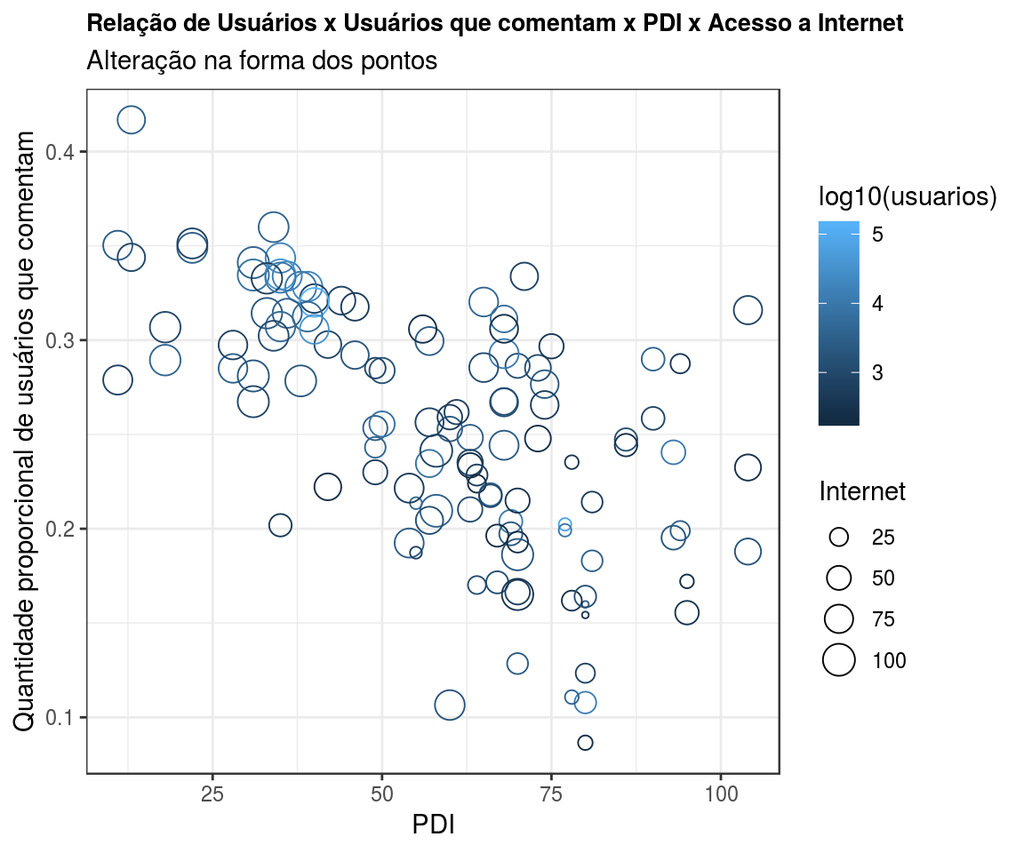

```r
analise1 = dados %>%
  select(comentaram_prop, PDI, Internet, usuarios) %>%
  ggplot(aes(
        x = PDI,
        y = comentaram_prop,
        size = Internet,
        color = log10(usuarios)
    )) +
  geom_point(shape=1) +
  theme(plot.title = element_text(size = 10, face = "bold")) +
    labs(
    title = "Relação de Usuários x Usuários que comentam x PDI x Acesso a Internet",
    subtitle = "Alteração na forma dos pontos",
    y = "Quantidade proporcional de usuários que comentam",
    x = "PDI"
  )

analise1
```

### 3 - Utilização do Espaço

```
Esse é um caso onde as labels são plotadas no gráfico, ao invés de uma categorização por legenda, dificultando assim, neste caso, a visualização por conta da má utilização do espaço
```

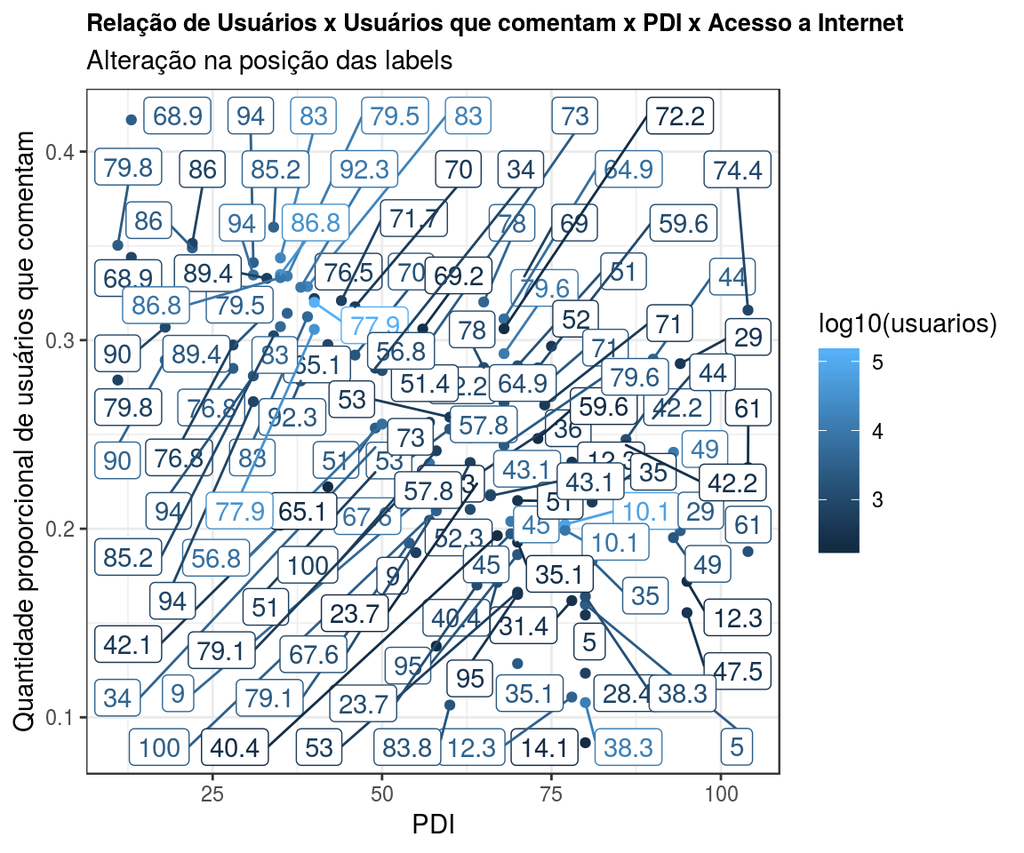

```r
#install.packages("ggrepel")
#devtools::install_github("GuangchuangYu/emojifont")

library(ggrepel)

#library(emojifont)
analise1 = dados %>%
  select(comentaram_prop, PDI, Internet, usuarios) %>%
  ggplot(aes(
        x = PDI,
        y = comentaram_prop,
        label = Internet,
        color = log10(usuarios)
    )) +
  geom_point() +
  geom_label_repel() +
  theme(plot.title = element_text(size = 10, face = "bold")) +
    labs(
    title = "Relação de Usuários x Usuários que comentam x PDI x Acesso a Internet",
    subtitle = "Alteração na posição das labels",
    y = "Quantidade proporcional de usuários que comentam",
    x = "PDI"
  )



analise1
```

### 4 - Volume (3D)

```
O exemplo abaixo mostra um exemplo de um canal menos eficiente para visualizações, o volume 3D.
```

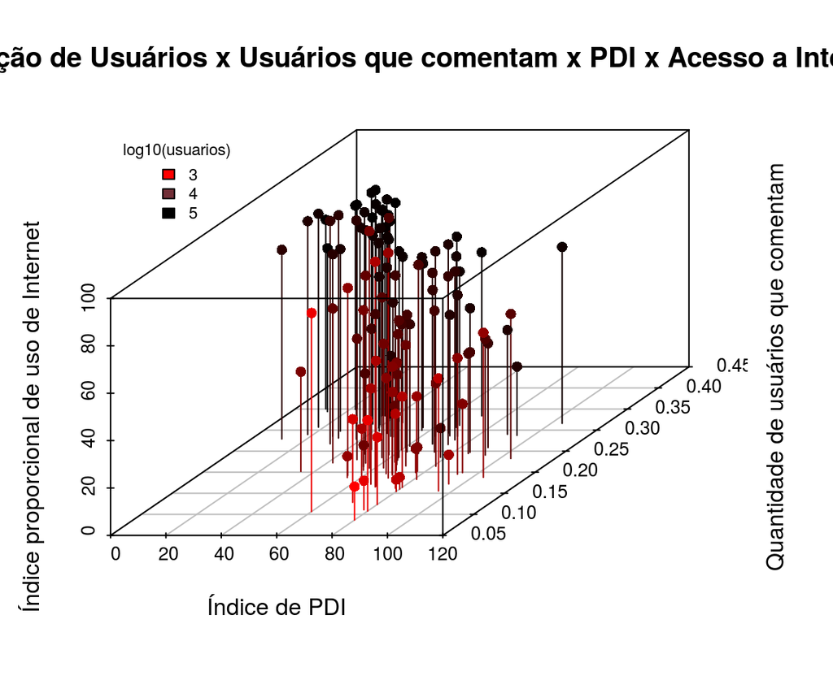

```r
#install.packages("fields")
library(scatterplot3d)

scatterplot3d(dados$PDI, dados$comentaram_prop, dados$Internet, color = log10(dados$usuarios), pch=16, highlight.3d = TRUE, type="h", main="Relação de Usuários x Usuários que comentam x PDI x Acesso a Internet", xlab="Índice de PDI", ylab="Quantidade de usuários que comentam", zlab="Índice proporcional de uso de Internet")
legend("topleft", inset=.05,      # location and inset
    bty="n", cex=.7,              # suppress legend box, shrink text 50%
    title="log10(usuarios)",
    c("3", "4", "5"), fill=c("red", "#722f37", "black"))
```

### 5 - Saturação Cor

```
A quantidade de saturação neste caso, dificulta diferenciar os valores da variável relacionada a quantidade de usuários (log(usuarios)).
```

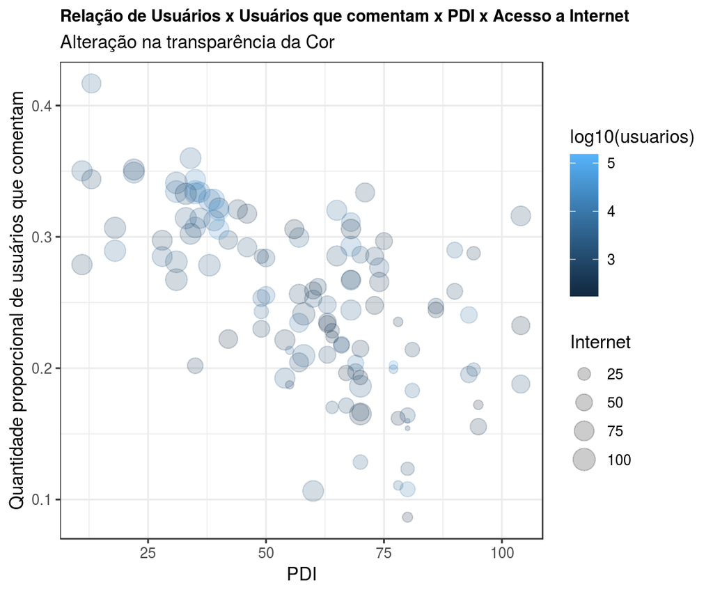

```r
analise1 = dados %>%
  select(comentaram_prop, PDI, Internet, usuarios) %>%
  ggplot(aes(
        x = PDI,
        y = comentaram_prop,
        size = Internet,
        color = log10(usuarios)
    )) +
  geom_point(alpha = 0.2) +
  theme(plot.title = element_text(size = 10, face = "bold")) +
    labs(
    title = "Relação de Usuários x Usuários que comentam x PDI x Acesso a Internet",
    subtitle = "Alteração na transparência da Cor",
    y = "Quantidade proporcional de usuários que comentam",
    x = "PDI"
  )


analise1
```

### 6 - Tamanho

A alteração do tamanho da área da forma no exemplo abaixo, dificulta a leitura dos valores da variável Proporção de acesso à Internet, pois foi plotada iniciando com valores menores em um grande tamanho, fazendo com que consequentemente, os tamanho sejam muito próximos e por isso, não permitindo uma boa diferenciação dos valores.

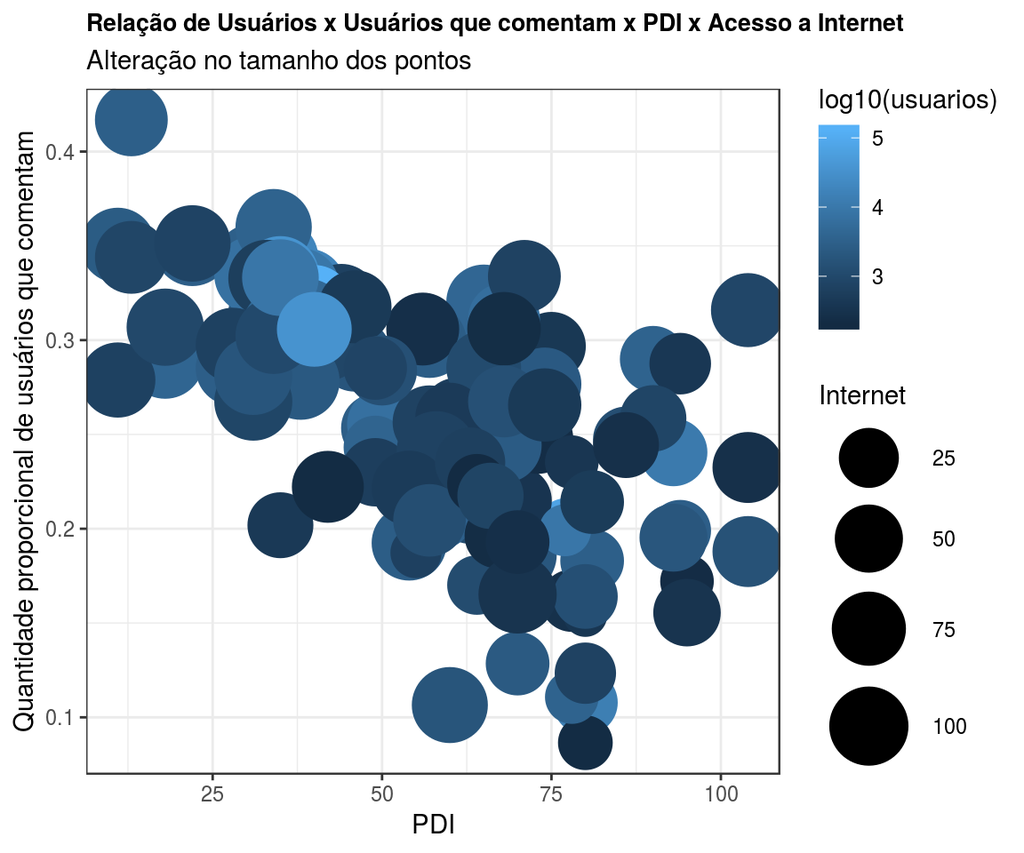

```r
analise1 = dados %>%
  select(comentaram_prop, PDI, Internet, usuarios) %>%
  ggplot(aes(
        x = PDI,
        y = comentaram_prop,
        size = Internet,
        color = log10(usuarios)
    )) +
  geom_point() +
  scale_size_continuous(range = c(8,15)) +
  theme(plot.title = element_text(size = 10, face = "bold")) +
    labs(
    title = "Relação de Usuários x Usuários que comentam x PDI x Acesso a Internet",
    subtitle = "Alteração no tamanho dos pontos",
    y = "Quantidade proporcional de usuários que comentam",
    x = "PDI"
  )


analise1
```

## Bônus

Inclua o continente dos países (`six_regions`) na visualização.

[output not shown]

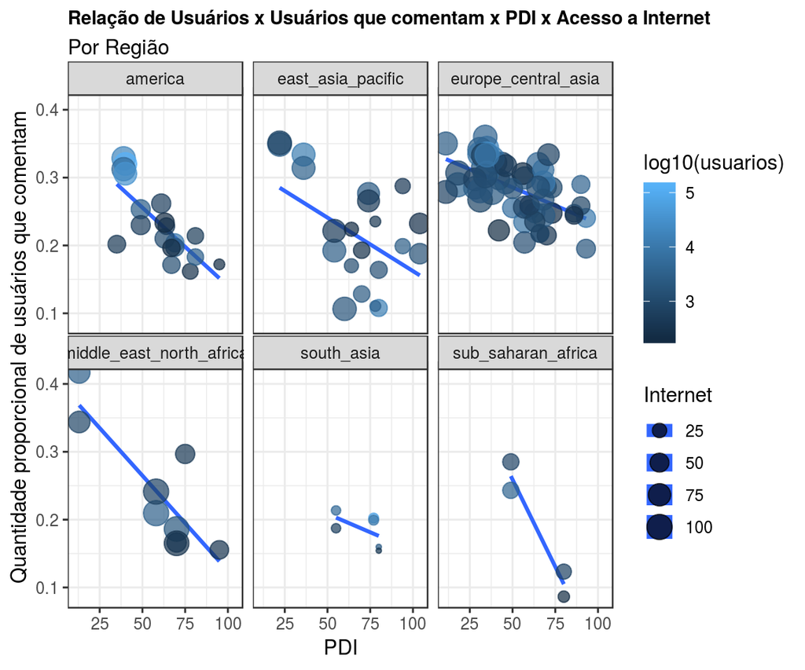

```r
analise1 = dados %>%
  filter(!is.na(six_regions)) %>%
  select(comentaram_prop, PDI, Internet, usuarios, six_regions) %>%
  ggplot(aes(
        x = PDI,
        y = comentaram_prop,
        size = Internet,
        color = log10(usuarios)
    )) +
  geom_smooth(aes(x = PDI, y = comentaram_prop), method = lm, se = FALSE) +
    facet_wrap(~ six_regions) +
    geom_point(alpha = .7) +
  theme(plot.title = element_text(size = 10, face = "bold")) +
    labs(
    title = "Relação de Usuários x Usuários que comentam x PDI x Acesso a Internet",
    subtitle = "Por Região",
    y = "Quantidade proporcional de usuários que comentam",
    x = "PDI"
  )

analise1
```

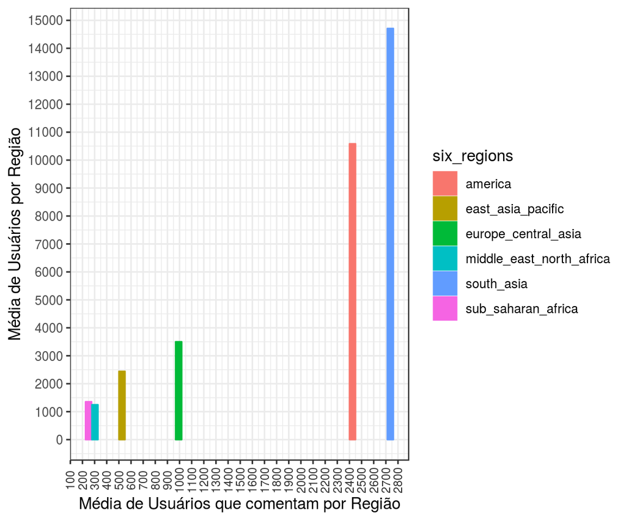

```r
analise = dados %>%
    filter(!is.na(six_regions)) %>%
    group_by(six_regions)  %>%
    summarise(media_usuarios = mean(usuarios), media_comentaram_prop = mean(comentaram_prop)*media_usuarios) %>%
    ggplot(aes(y = media_usuarios, x = media_comentaram_prop, color = six_regions)) +
    geom_bar(
      aes(color = six_regions, fill = six_regions),
      stat = "identity", position = position_dodge(0.8),
      width = 50
    ) +
    ylab("Média de Usuários por Região") +
    xlab("Média de Usuários que comentam por Região") +
    scale_x_continuous(breaks = seq(from = 0, to = 30000, by = 100)) +
    scale_y_continuous(breaks = seq(from = 0, to = 30000, by = 1000)) +
    theme(axis.text.x = element_text(color = "grey20", size = 8, angle = 90, hjust = .5, vjust = .5, face = "plain"))
analise
```